# Code_Feature_Engineering

## Load the dataset

```python
# Import the necessary libraries
import pandas as pd
import numpy as np
import matplotlib.pyplot as plt
import seaborn as sns
import os

# Load the dataset from Colab
from google.colab import files
uploaded = files.upload()
```

Upload widget is only available when the cell has been executed in the current browser session. Please rerun this cell to enable.

```
Saving test_df_transformed (3).csv to test_df_transformed (3).csv
Saving train_df_transformed (5).csv to train_df_transformed (5).csv
```

```python
# Read the dataset
df = pd.read_csv('df.csv')
train_all = pd.read_csv('train_all.csv')
test_all = pd.read_csv('test_all.csv')
train_df_transformed = pd.read_csv('train_df_transformed (5).csv')
test_df_transformed = pd.read_csv('test_df_transformed (3).csv')
df_transformed = pd.read_csv('df_transformed (9).csv')

# Print the first few rows
print(train_all.head())
print(test_all.head())
print(train_df_transformed.head())
print(test_df_transformed.head())
print(df_transformed.head(9))
```

```
   Cost of a healthy diet  Income  Inflation  Child mortality rate  \
0                    -1.0    -1.0    9.68342             41.370100
1                    -1.0    -1.0    9.68342             40.799400
2                    -1.0    -1.0    9.68342             40.224000
3                    -1.0    -1.0    9.68342             39.642300
4                    -1.0    -1.0    9.68342             39.158897

   Unemployment Rate  Life expectancy  Incomplete tertiary education  \
0             6.9405          28.1563                            0.3
1             6.9405          28.5836                            0.3
2             6.9405          29.0138                            0.3
3             6.9405          29.4521                            0.3
4             6.9405          29.6975                            0.3

   Gini coefficient  Diabetes  BMI (female)  Cardiovascular diseases  \
```

[output cut: 150 more lines]

## Multicollinearity Check using VIF

Variance Inflation Factor (VIF) measures how much the variance of a regression coefficient is inflated due to multicollinearity among predictor variables. Multicollinearity occurs when predictors are highly correlated with each other, which can lead to unstable coefficient estimates, inflated standard errors, and difficulty in interpreting the individual effects of variables.

VIF with values above 5 or 10 typically indicating problematic multicollinearity. Using VIF helps identify redundant features, guides feature selection, and improves model interpretability by ensuring stable and meaningful coefficient estimates.

For this dataset, which includes continuous numeric variables such as GDP and Income, and uses linear regression models to analyze health outcomes like life expectancy and cardiovascular diseases.

This approach is supported by foundational econometrics and statistical learning literature, including works by Gujarati (2003) and James et al. (2013), as well as applied health research where socioeconomic and health indicators often exhibit correlations.

Overall, incorporating VIF checks enhances the reliability of your regression models, especially when interpreting the impact of predictors.

```python
# VIF Test for checking multicollinarity

from statsmodels.stats.outliers_influence import variance_inflation_factor
from statsmodels.tools.tools import add_constant
import pandas as pd

# Select the features for VIF calculation (excluding target variables)
vif_features = [
    'Income', 'GDP', 'CPI', 'Sex ratio', 'BMI (female)', 'Cost of a healthy diet',
    'Inflation', 'Incomplete tertiary education', 'Gini coefficient', 'Median age',
    'BMI (male)', 'Unemployment Rate', 'Child mortality rate'
]

# Drop rows with missing values
vif_data = train_all[vif_features].dropna()

# Add constant term for intercept
vif_data_const = add_constant(vif_data)

# Calculate VIF
vif_df = pd.DataFrame()
vif_df["Feature"] = vif_data_const.columns
vif_df["VIF"] = [variance_inflation_factor(vif_data_const.values, i) for i in range(vif_data_const.shape[1])]

# Display VIF values
print("\nVariance Inflation Factors:")
print(vif_df)
```

```
Variance Inflation Factors:
                          Feature       VIF
0                           const  0.000000
1                          Income  1.338307
2                             GDP  1.024624
3                             CPI  1.003511
4                       Sex ratio  1.126552
5                    BMI (female)  6.641593
6          Cost of a healthy diet  1.246448
7                       Inflation  1.001940
8   Incomplete tertiary education  1.095969
9                Gini coefficient  1.272552
10                     Median age  1.569114
11                     BMI (male)  7.140645
12              Unemployment Rate  1.083354
13           Child mortality rate  1.567488
```

```python
# Combine variable BMI(female) and BMI(male) by using their average for dataset

# Create combined BMI feature
df['BMI_avg'] = (df['BMI (female)'] + df['BMI (male)']) / 2

# Drop the original columns
df.drop(['BMI (female)', 'BMI (male)'], axis=1, inplace=True)
```

```python
# Combine variable BMI(female) and BMI(male) by using their average for train set and test set

# Create combined BMI feature for train and test set
train_all['BMI_avg'] = (train_all['BMI (female)'] + train_all['BMI (male)']) / 2
test_all['BMI_avg'] = (test_all['BMI (female)'] + test_all['BMI (male)']) / 2

# Drop the original columns
train_all.drop(['BMI (female)', 'BMI (male)'], axis=1, inplace=True)
test_all.drop(['BMI (female)', 'BMI (male)'], axis=1, inplace=True)

# Check first few column
print("Train Set")
print(train_all.head())
print("Test Set")
print(test_all.head())
```

```
Train Set
   Cost of a healthy diet  Income  Inflation  Child mortality rate  \
0                    -1.0    -1.0    9.68342             41.370100
1                    -1.0    -1.0    9.68342             40.799400
2                    -1.0    -1.0    9.68342             40.224000
3                    -1.0    -1.0    9.68342             39.642300
4                    -1.0    -1.0    9.68342             39.158897

   Unemployment Rate  Life expectancy  Incomplete tertiary education  \
0             6.9405          28.1563                            0.3
1             6.9405          28.5836                            0.3
2             6.9405          29.0138                            0.3
3             6.9405          29.4521                            0.3
4             6.9405          29.6975                            0.3

```

[output cut: 41 more lines]

```python
# VIF Test again after combined a new variable BMI_avg

# VIF Test for checking multicollinarity

# Select the features for VIF calculation (excluding target variables)
vif_features = [
    'Income', 'GDP', 'CPI', 'Sex ratio', 'BMI_avg', 'Cost of a healthy diet',
    'Inflation', 'Incomplete tertiary education', 'Gini coefficient', 'Median age',
    'Unemployment Rate', 'Child mortality rate'
]

# Drop rows with missing values
vif_data = train_all[vif_features].dropna()

# Add constant term for intercept
vif_data_const = add_constant(vif_data)

# Calculate VIF
vif_df = pd.DataFrame()
vif_df["Feature"] = vif_data_const.columns
vif_df["VIF"] = [variance_inflation_factor(vif_data_const.values, i) for i in range(vif_data_const.shape[1])]

# Display VIF values
print("\nVariance Inflation Factors:")
print(vif_df)
```

```
Variance Inflation Factors:
                          Feature       VIF
0                           const  0.000000
1                          Income  1.151946
2                             GDP  1.021710
3                             CPI  1.003505
4                       Sex ratio  1.123716
5                         BMI_avg  1.099278
6          Cost of a healthy diet  1.246317
7                       Inflation  1.001889
8   Incomplete tertiary education  1.089855
9                Gini coefficient  1.264301
10                     Median age  1.521325
11              Unemployment Rate  1.067065
12           Child mortality rate  1.559535
```

# Lag Feature

Lag features are values from previous time steps used as predictors to forecast current or future values.

It suitable to apply for RQ3 forecasting life expectancy, diabetes, or heart disease over time. Lag features will help Prophet and regression models capture dependencies across years more effectively. ARIMA and Random Forest will create lag internally.

Lag is important because it helps to identify patterns and relationships between past and present data points. Time series models, such as ARIMA, heavily rely on lag to capture autocorrelations (the correlation between observations at different time lags) in the data.

Key reasons why lag is essential:

Autocorrelation Detection: Lag enables analysts to understand how current data points are related to previous ones. If there is a significant autocorrelation at a particular lag, it suggests that past values can be used to predict future values. Feature Creation: In machine learning models for time series forecasting, lagged variables are often used as features. These features represent the values of the time series at previous time steps, allowing the model to learn patterns over time. Trend Identification: By observing how values change across different lags, trends and seasonality can be identified. For instance, a consistent increase in lagged values may indicate an upward trend.

In ARIMA, the model forecasts a time series based on the linear relationship between an observation and a number of lagged observations.

Several prior studies proof that Lag Feature is a crucial technique for time series modeling, such as ARIMA, Prophet and Random Forest.

Debón et al. (2017) used lagged mortality rates to forecast life expectancy in European countries. Wang et al. (2019) – used lagged environmental and health variables to predict life expectancy and disease incidence in China. And Chakraborty et al. (2020) – used lagged economic indicators to predict diabetes trends in India.

```python
# lag feature - REVISED - lag after train test set

import pandas as pd

# === STEP 1: Ensure 'Country' and 'Year' are columns (if set as index)
if train_df_transformed.index.names == ['Country', 'Year']:
    train_df_transformed = train_df_transformed.reset_index()

if test_df_transformed.index.names == ['Country', 'Year']:
    test_df_transformed = test_df_transformed.reset_index()

# === STEP 2: Set MultiIndex for lagging
train_df_transformed = train_df_transformed.set_index(['Country', 'Year']).sort_index()
test_df_transformed = test_df_transformed.set_index(['Country', 'Year']).sort_index()

# === STEP 3: Define target and predictor columns
target_cols = ['Life expectancy', 'Cardiovascular diseases', 'Diabetes']
predictors = [col for col in train_df_transformed.columns if col not in target_cols and col != 'lagged']

# === STEP 4: Function to create lag features (only on train set)
def create_lag_features(df, cols, lags=[1, 2, 3]):
    df_lag = df.copy()
    for col in cols:
        for lag in lags:
            df_lag[f'{col}_lag{lag}'] = df_lag.groupby(level='Country')[col].shift(lag)
    return df_lag

train_lagged = create_lag_features(train_df_transformed, predictors)

# === STEP 5: Impute missing lag values in training set (from early years like 1950–1952)
train_lagged = (
    train_lagged
    .reset_index()
    .groupby('Country', group_keys=False)
    .apply(lambda x: x.sort_values('Year').ffill().bfill())
    .reset_index(drop=True)
    .set_index(['Country', 'Year']).sort_index()
)

# === STEP 6: Add a flag for lagged data (optional, useful for debugging)
train_lagged['lagged'] = True
test_df_transformed['lagged'] = False

# === STEP 7: Combine train and test into full set for modeling/prediction
df_combined = pd.concat([train_lagged, test_df_transformed])
df_combined = df_combined.reset_index()
df_combined = df_combined.sort_values(['Country', 'Year']).drop_duplicates(subset=['Country', 'Year'], keep='last')
df_combined = df_combined.set_index(['Country', 'Year']).sort_index()

# === STEP 8: Final safety fill to ensure no missing cells (optional)
df_combined = (
    df_combined
    .reset_index()
    .groupby('Country', group_keys=False)
    .apply(lambda x: x.sort_values('Year').ffill().bfill())
    .reset_index(drop=True)
    .set_index(['Country', 'Year']).sort_index()
)

# === STEP 9: Reset index for modeling
df_combined_with_country = df_combined.reset_index()

# === STEP 10: Check sample of lag features
lag_cols = [f'{col}_lag{lag}' for col in predictors for lag in [1, 2, 3]]
print("\n✅ Final Combined Dataset (1950–2023) with Lag Features — No Missing Values:")
print(df_combined_with_country[['Country', 'Year'] + lag_cols].head(10))

# export and download file
df_combined_with_country.to_csv("df_combined_with_country.csv", index=False)

from google.colab import files
files.download("df_combined_with_country.csv")
```

```
✅ Final Combined Dataset (1950–2023) with Lag Features — No Missing Values:
       Country  Year  Cost of a healthy diet_lag1  \
0  Afghanistan  1950                     0.871262
1  Afghanistan  1951                     0.871262
2  Afghanistan  1952                     0.871262
3  Afghanistan  1953                     0.871262
4  Afghanistan  1954                     0.871262
5  Afghanistan  1955                     0.871262
6  Afghanistan  1956                     0.871262
7  Afghanistan  1957                     0.871262
8  Afghanistan  1958                     0.871262
9  Afghanistan  1959                     0.871262

   Cost of a healthy diet_lag2  Cost of a healthy diet_lag3  Income_lag1  \
0                     0.871262                     0.871262     1.069802
```

[output cut: 47 more lines]

## Restore Index - Country and Year

```python
## restore Country and year for df_transformed
# Restore index — only if not already set
if 'Country' not in df_transformed.index.names or 'Year' not in df_transformed.index.names:
    df_transformed = df_transformed.set_index(['Country', 'Year'])

# Optional: sort for time-aware operations
df_transformed = df_transformed.sort_index()

# Preview index structure
print("✅ Index restored — here’s a sample:")
print(df_transformed.head())
```

```
✅ Index restored — here’s a sample:
                  Cost of a healthy diet    Income  Inflation  \
Country     Year
Afghanistan 1950                0.871262  1.069802   2.119237
            1951                0.871262  1.069802   2.119237
            1952                0.871262  1.069802   2.119237
            1953                0.871262  1.069802   2.119237
            1954                0.871262  1.069802   2.119237

                  Child mortality rate  Unemployment Rate  Life expectancy  \
Country     Year
Afghanistan 1950              3.288735           1.968604          28.1563
            1951              3.288735           1.968604          28.5836
            1952              3.288735           1.968604          29.0138
            1953              3.288735           1.968604          29.4521
            1954              3.288735           1.968604          29.6975

                  Incomplete tertiary education  Gini coefficient  Diabetes  \
Country     Year
Afghanistan 1950                        0.26709          0.140308       6.2
            1951                        0.26709          0.140308       6.2
            1952                        0.26709          0.140308       6.2
            1953                        0.26709          0.140308       6.2
            1954                        0.26709          0.140308       6.2

                  Cardiovascular diseases  Sex ratio        GDP  Median age  \
Country     Year
Afghanistan 1950                  3.97278   0.268828  26.976456    0.704301
            1951                  3.97278   0.268828  26.976456    0.704280
            1952                  3.97278   0.268828  26.976456    0.704250
            1953                  3.97278   0.268828  26.976456    0.704213
            1954                  3.97278   0.268828  26.976456    0.704172

                       CPI    BMI_avg  lagged
Country     Year
Afghanistan 1950  9.172623  26.023944   False
            1951  9.172623  26.023944   False
            1952  9.172623  26.023944   False
            1953  9.172623  26.023944   False
            1954  9.172623  26.023944   False
```

# Identify the Best Feature Selection Method and The Best Number of Features for Modeling

1. LASSO (Least Absolute Shrinkage and Selection Operator)
2. RFE (Recursive Feature Elimination)
3. Forward Selection
4. Random Forest Each method selects features based on different principles, and for each method, the code evaluates models using a different number of features—starting from 1 up to a maximum (e.g., 15). For each configuration (method + number of features), the model’s performance is assessed using TimeSeriesSplit cross-validation and Root Mean Squared Error (RMSE) as the evaluation metric. The process is repeated for each of your target variables separately. The method and feature count with the lowest RMSE is considered optimal for that target.

# Feature Selection Comparison (Summary and Charts)

Compare Feature Selection method and the best nubmer of features using RMSE

```
🔍 Feature selection for target: Cardiovascular diseases

Method: LASSO
Best number of features: 1
Best RMSE: 145.0757
Selected features: ['GDP']

Method: RFE
Best number of features: 3
Best RMSE: 144.5297
Selected features: ['Income', 'BMI (male)', 'GDP']

Method: Forward
Best number of features: 11
Best RMSE: 145.4053
Selected features: ['Unemployment Rate', 'Incomplete tertiary education', 'GDP', 'Unemployment Rate_lag1', 'Unemployment Rate_lag2', 'Unemployment Rate_lag3', 'Incomplete tertiary education_lag1', 'Incomplete tertiary education_lag2', 'Incomplete tertiary education_lag3', 'GDP_lag1', 'lagged']

Method: RandomForest
Best number of features: 3
Best RMSE: 145.3746
Selected features: ['Inflation', 'GDP', 'Incomplete tertiary education']
```

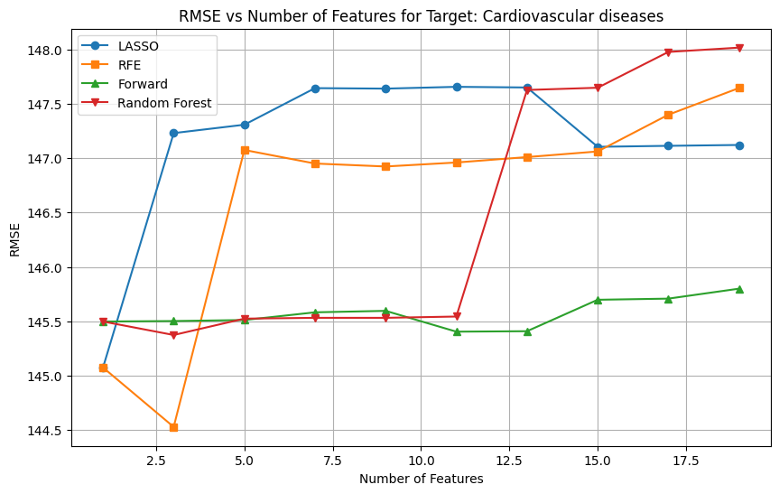

```
🔍 Feature selection for target: Diabetes

Method: LASSO
Best number of features: 9
Best RMSE: 3.6615
Selected features: ['Incomplete tertiary education', 'CPI', 'Median age_lag3', 'BMI (male)_lag3', 'Cost of a healthy diet', 'GDP', 'Income', 'BMI (female)', 'BMI (female)_lag3']

Method: RFE
Best number of features: 13
Best RMSE: 3.6531
Selected features: ['Cost of a healthy diet', 'Income', 'Inflation', 'Incomplete tertiary education', 'Gini coefficient', 'BMI (female)', 'GDP', 'CPI', 'Income_lag3', 'BMI (female)_lag3', 'BMI (male)_lag3', 'Sex ratio_lag3', 'Median age_lag3']

Method: Forward
Best number of features: 11
Best RMSE: 3.6466
Selected features: ['Income', 'Inflation', 'Child mortality rate', 'BMI (male)', 'Sex ratio', 'GDP', 'Cost of a healthy diet_lag1', 'Income_lag1', 'Inflation_lag1', 'BMI (female)_lag3', 'Sex ratio_lag3']

Method: RandomForest
Best number of features: 9
Best RMSE: 3.6751
Selected features: ['Incomplete tertiary education', 'BMI (male)', 'Income', 'BMI (male)_lag3', 'GDP', 'BMI (female)_lag2', 'BMI (female)_lag1', 'BMI (female)_lag3', 'BMI (female)']
```

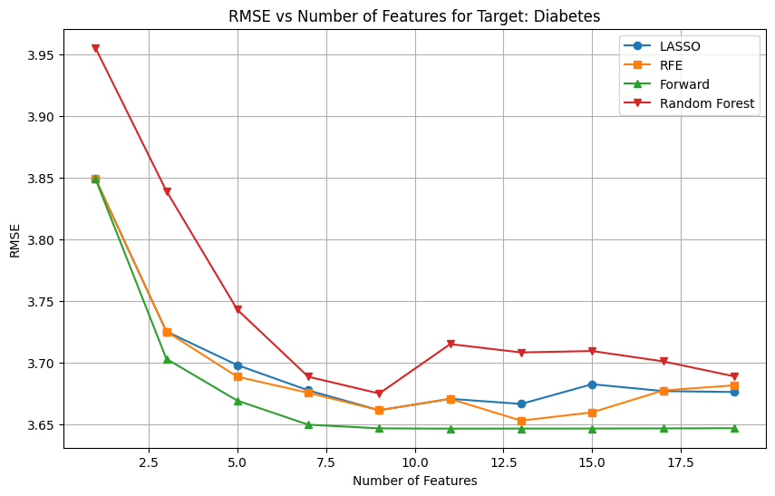

```
🔍 Feature selection for target: Life expectancy

Method: LASSO
Best number of features: 5
Best RMSE: 3.5032
Selected features: ['Median age_lag3', 'GDP', 'Sex ratio', 'Child mortality rate_lag3', 'Child mortality rate']

Method: RFE
Best number of features: 5
Best RMSE: 3.5387
Selected features: ['Child mortality rate', 'Median age', 'Child mortality rate_lag2', 'Child mortality rate_lag3', 'Median age_lag3']

Method: Forward
Best number of features: 11
Best RMSE: 3.4962
Selected features: ['Child mortality rate', 'Sex ratio', 'GDP', 'Child mortality rate_lag1', 'Child mortality rate_lag2', 'Child mortality rate_lag3', 'BMI (female)_lag3', 'Sex ratio_lag1', 'Sex ratio_lag2', 'Sex ratio_lag3', 'lagged']

Method: RandomForest
Best number of features: 9
Best RMSE: 3.5058
Selected features: ['Child mortality rate_lag1', 'GDP', 'Sex ratio', 'Income', 'Median age_lag3', 'Median age', 'Child mortality rate_lag2', 'Child mortality rate_lag3', 'Child mortality rate']
```

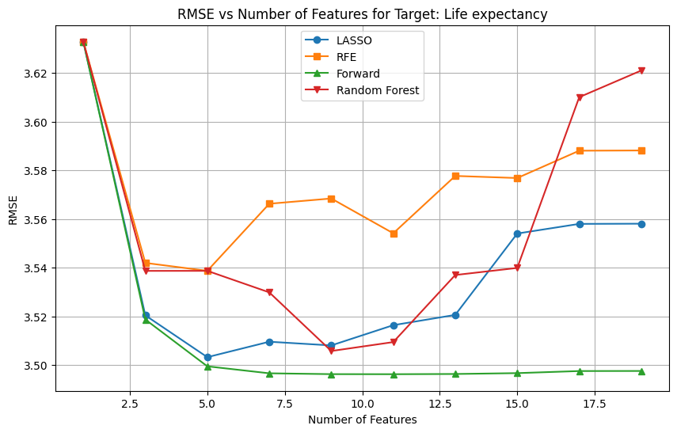

```python
# feature selection comparison
from sklearn.linear_model import Ridge
from sklearn.impute import SimpleImputer

def find_best_feature_count(X_df, y, max_features=None):
    import numpy as np
    import pandas as pd
    from sklearn.linear_model import LassoCV, LinearRegression
    from sklearn.feature_selection import RFE, SequentialFeatureSelector
    from sklearn.ensemble import RandomForestRegressor
    from sklearn.model_selection import TimeSeriesSplit
    from sklearn.metrics import mean_squared_error
    from sklearn.preprocessing import StandardScaler

    feature_names = X_df.columns.tolist()

    # 1. Impute missing values
    imputer = SimpleImputer(strategy='mean')  # or 'median', 'most_frequent'
    X_imputed = imputer.fit_transform(X_df)
    y_imputed = imputer.fit_transform(y.values.reshape(-1, 1)).ravel()

    # --- Scale X and y ---
    scaler = StandardScaler()
    X_scaled = scaler.fit_transform(X_imputed)

    y_imputed = y_imputed.reshape(-1, 1)
    y_scaler = StandardScaler()
    y_scaled = y_scaler.fit_transform(y_imputed).ravel()
    y_original = y_imputed.ravel()

      #y_scaled = y_scaler.fit_transform(y).ravel()
    #y_original = y.ravel()

    tscv = TimeSeriesSplit(n_splits=3)

    def rmse_on_original_scale(model, X_subset):
        y_preds, y_tests = [], []
        for train_idx, test_idx in tscv.split(X_subset):
            model.fit(X_subset[train_idx], y_scaled[train_idx])
            y_pred_scaled = model.predict(X_subset[test_idx])
            y_pred_original = y_scaler.inverse_transform(y_pred_scaled.reshape(-1, 1)).ravel()
            y_preds.extend(y_pred_original)
            y_tests.extend(y_original[test_idx])
        return np.sqrt(mean_squared_error(y_tests, y_preds))

    # --- Feature Selection ---
    max_features = min(max_features or 20, X_scaled.shape[1] - 1)
    lasso = LassoCV(cv=tscv, random_state=42).fit(X_scaled, y_scaled)
    lasso_coef = lasso.coef_
    rf_model = RandomForestRegressor(n_estimators=100, random_state=42)
    rf_model.fit(X_scaled, y_scaled)
    importances = rf_model.feature_importances_

    lasso_rmse_list, rfe_rmse_list, sfs_rmse_list, rf_rmse_list = [], [], [], []

    step = 2
    for n in range(1, max_features + 1, step):
        idx_lasso = np.argsort(np.abs(lasso_coef))[-n:]
        X_lasso = X_scaled[:, idx_lasso]
        lasso_rmse_list.append((n, rmse_on_original_scale(LinearRegression(), X_lasso)))

        try:
            rfe = RFE(LinearRegression(), n_features_to_select=n)
            X_rfe = rfe.fit_transform(X_scaled, y_scaled)
            rfe_rmse_list.append((n, rmse_on_original_scale(LinearRegression(), X_rfe)))
        except:
            rfe_rmse_list.append((n, np.nan))

        try:
            sfs = SequentialFeatureSelector(LinearRegression(), n_features_to_select=n, direction='forward', cv=tscv, n_jobs=-1)
            X_sfs = sfs.fit_transform(X_scaled, y_scaled)
            sfs_rmse_list.append((n, rmse_on_original_scale(LinearRegression(), X_sfs)))
        except:
            sfs_rmse_list.append((n, np.nan))

        idx_rf = np.argsort(importances)[-n:]
        X_rf = X_scaled[:, idx_rf]
        rf_rmse_list.append((n, rmse_on_original_scale(LinearRegression(), X_rf)))

    df_combined = (
        pd.DataFrame(lasso_rmse_list, columns=['n_features', 'LASSO_RMSE'])
        .merge(pd.DataFrame(rfe_rmse_list, columns=['n_features', 'RFE_RMSE']), on='n_features')
        .merge(pd.DataFrame(sfs_rmse_list, columns=['n_features', 'Forward_RMSE']), on='n_features')
        .merge(pd.DataFrame(rf_rmse_list, columns=['n_features', 'RF_RMSE']), on='n_features')
    )

    # --- Feature Names ---
    best_lasso_n = df_combined.loc[df_combined['LASSO_RMSE'].idxmin(), 'n_features']
    best_rfe_n = df_combined.loc[df_combined['RFE_RMSE'].idxmin(), 'n_features']
    best_sfs_n = df_combined.loc[df_combined['Forward_RMSE'].idxmin(), 'n_features']
    best_rf_n = df_combined.loc[df_combined['RF_RMSE'].idxmin(), 'n_features']

    lasso_features = [feature_names[i] for i in np.argsort(np.abs(lasso_coef))[-best_lasso_n:]]
    rfe = RFE(LinearRegression(), n_features_to_select=best_rfe_n).fit(X_scaled, y_scaled)
    rfe_features = [feature_names[i] for i, flag in enumerate(rfe.support_) if flag]
    sfs = SequentialFeatureSelector(LinearRegression(), n_features_to_select=best_sfs_n, direction='forward', cv=tscv).fit(X_scaled, y_scaled)
    sfs_features = [feature_names[i] for i, flag in enumerate(sfs.get_support()) if flag]
    rf_features = [feature_names[i] for i in np.argsort(importances)[-best_rf_n:]]

    best_methods = {
        'LASSO': {'n_features': best_lasso_n, 'rmse': df_combined.loc[df_combined['n_features'] == best_lasso_n, 'LASSO_RMSE'].values[0], 'features': lasso_features},
        'RFE': {'n_features': best_rfe_n, 'rmse': df_combined.loc[df_combined['n_features'] == best_rfe_n, 'RFE_RMSE'].values[0], 'features': rfe_features},
        'Forward': {'n_features': best_sfs_n, 'rmse': df_combined.loc[df_combined['n_features'] == best_sfs_n, 'Forward_RMSE'].values[0], 'features': sfs_features},
        'RandomForest': {'n_features': best_rf_n, 'rmse': df_combined.loc[df_combined['n_features'] == best_rf_n, 'RF_RMSE'].values[0], 'features': rf_features}
    }

    return df_combined, best_methods

import matplotlib.pyplot as plt

target_cols = ['Cardiovascular diseases', 'Diabetes', 'Life expectancy']
results = {}

for target in target_cols:
    lag_cols = [f'{target}_lag1', f'{target}_lag2']
    cols_to_drop = target_cols + [col for col in lag_cols if col in df_lagged.columns]
    X = df_lagged.drop(columns=cols_to_drop)
    y = df_lagged[target]

    print(f"\n🔍 Feature selection for target: {target}")
    df_combined, best_methods = find_best_feature_count(X, y)
    results[target] = {'df_combined': df_combined, 'best_methods': best_methods}

    for method, info in best_methods.items():
        print(f"\nMethod: {method}")
        print(f"Best number of features: {info['n_features']}")
        print(f"Best RMSE: {info['rmse']:.4f}")
        print(f"Selected features: {info['features']}")

    plt.figure(figsize=(10,6))
    plt.plot(df_combined['n_features'], df_combined['LASSO_RMSE'], label='LASSO', marker='o')
    plt.plot(df_combined['n_features'], df_combined['RFE_RMSE'], label='RFE', marker='s')
    plt.plot(df_combined['n_features'], df_combined['Forward_RMSE'], label='Forward', marker='^')
    plt.plot(df_combined['n_features'], df_combined['RF_RMSE'], label='Random Forest', marker='v')
    plt.xlabel('Number of Features')
    plt.ylabel('RMSE')
    plt.title(f'RMSE vs Number of Features for Target: {target}')
    plt.grid(True)
    plt.legend()
    plt.show()
```

## Feature selection Comparison with R sq, MAPE, MSE (Summary and Charts)

Compare Feature selection and the best number of features using Metrics (R square, MAPE, MSE)

```
🔍 Evaluating for target: Life expectancy
```

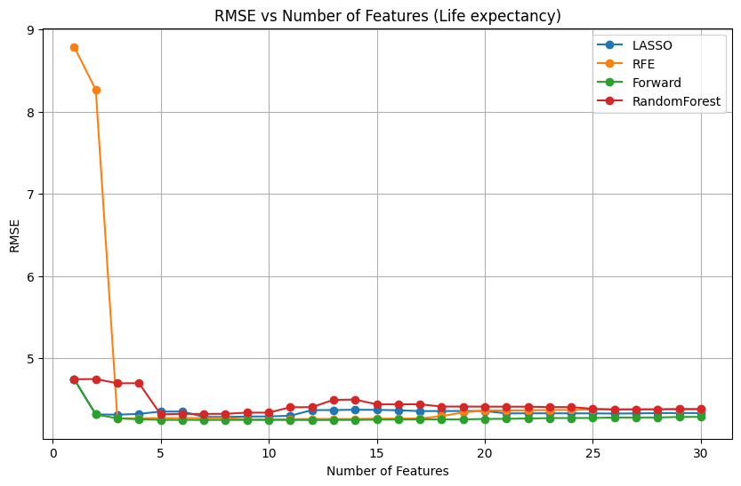

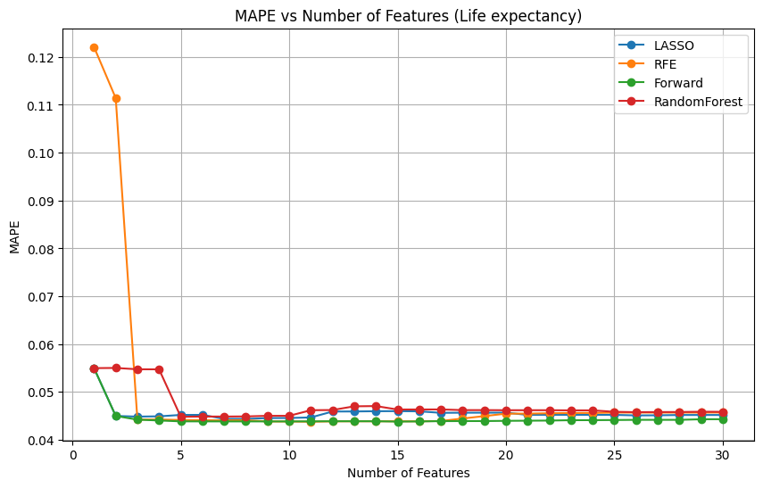

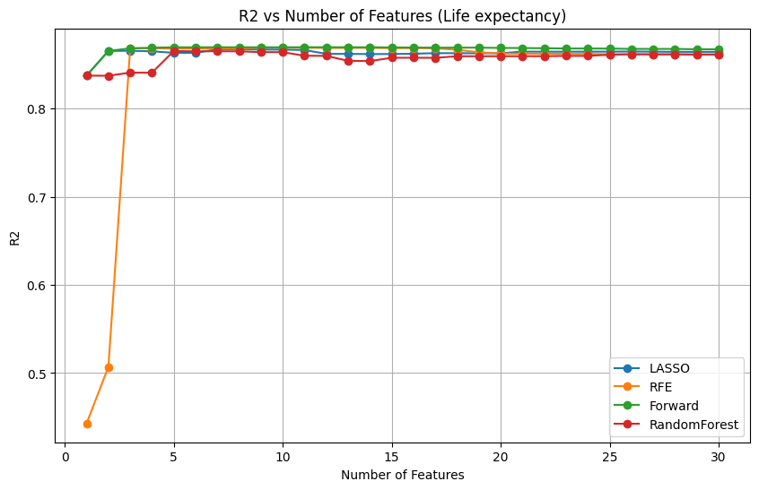

```
🔍 Evaluating for target: Cardiovascular diseases
```

[output not shown]

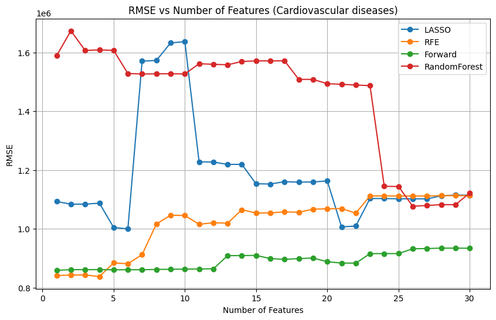

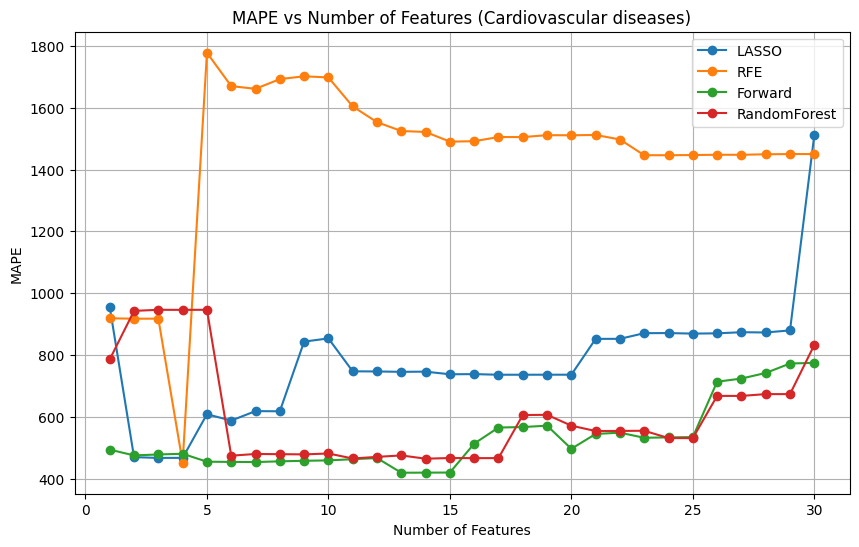

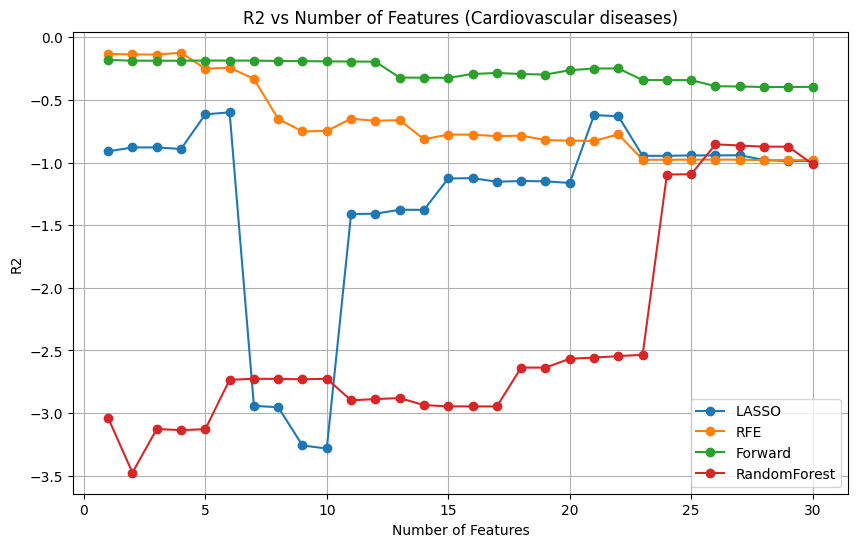

```
🔍 Evaluating for target: Diabetes
```

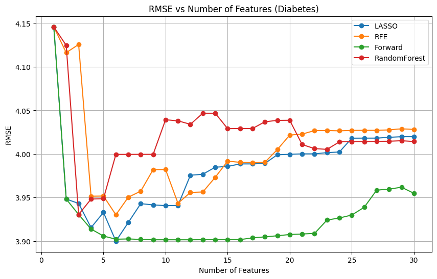

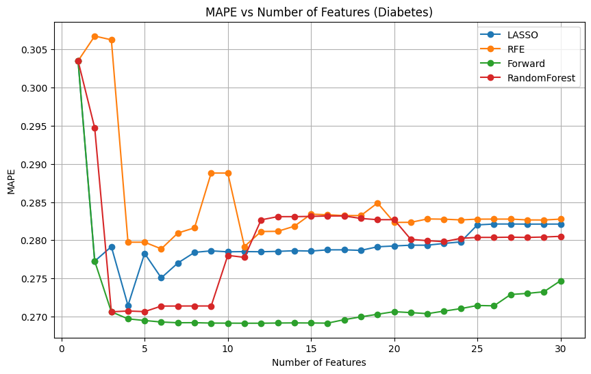

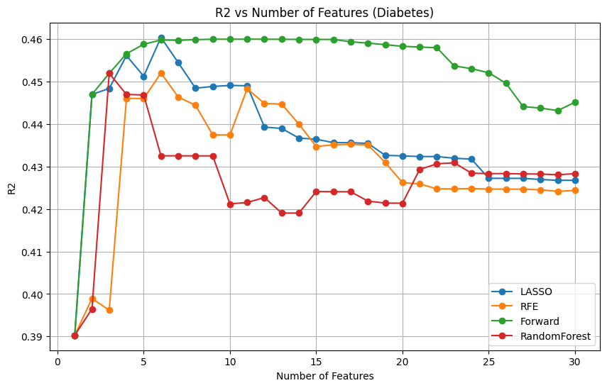

```python
# Feature selection with R sq, MAPE, MSE

import numpy as np
import pandas as pd
import matplotlib.pyplot as plt
from sklearn.linear_model import LassoCV, LinearRegression
from sklearn.feature_selection import RFE, SequentialFeatureSelector
from sklearn.ensemble import RandomForestRegressor
from sklearn.model_selection import TimeSeriesSplit
from sklearn.metrics import mean_squared_error, mean_absolute_percentage_error, r2_score
from sklearn.preprocessing import StandardScaler

# Move plot_metrics function definition to the beginning
def plot_metrics(df_combined, target_name):
     metrics = ['RMSE', 'MAPE', 'R2']
     methods = ['LASSO', 'RFE', 'Forward', 'RandomForest']

     for metric in metrics:
         plt.figure(figsize=(10,6))
         for method in methods:
             # Check if the metric column exists for the method before plotting
             metric_col = f'{method}_{metric}'
             if metric_col in df_combined.columns:
                 plt.plot(df_combined['n_features'], df_combined[metric_col], label=method, marker='o')
             else:
                 print(f"Warning: Metric column '{metric_col}' not found in DataFrame for plotting.")

         plt.title(f'{metric} vs Number of Features ({target_name})')
         plt.xlabel('Number of Features')
         plt.ylabel(metric)
         plt.legend()
         plt.grid(True)
         plt.show()


def evaluate_model(model, X_subset, y_scaled, y_original, y_scaler, tscv):
    y_preds, y_tests = [], []
    # Ensure X_subset and y_scaled have the same index for splitting
    # Convert X_subset to DataFrame if it's numpy array to use index for splitting
    if not isinstance(X_subset, pd.DataFrame):
        # Assuming X_subset corresponds to the same rows as y_scaled
        X_subset_df = pd.DataFrame(X_subset, index=pd.Series(y_scaled).index)
    else:
        X_subset_df = X_subset

    for train_idx, test_idx in tscv.split(X_subset_df): # Use X_subset_df for splitting
        # Select data using indices from the split
        X_train, X_test = X_subset_df.iloc[train_idx], X_subset_df.iloc[test_idx]
        y_train_scaled, y_test_scaled = y_scaled[train_idx], y_scaled[test_idx]
        y_test_original = y_original[test_idx] # Select original y for test set


        # Ensure there's data in train and test sets for the current fold
        if len(X_train) > 0 and len(X_test) > 0:
            try:
                model.fit(X_train, y_train_scaled)
                y_pred_scaled = model.predict(X_test)
                y_pred_original = y_scaler.inverse_transform(y_pred_scaled.reshape(-1, 1)).ravel()
                y_preds.extend(y_pred_original)
                y_tests.extend(y_test_original)
            except Exception as e:
                 print(f"Error during model fitting or prediction in a fold: {e}")
                 # Extend with NaNs or skip if error occurs in a fold
                 y_preds.extend([np.nan] * len(y_test_original))
                 y_tests.extend(y_test_original) # Still add the test actuals to keep lists aligned

    # Calculate metrics only if y_tests and y_preds are not empty and don't contain NaNs/Infs
    y_tests_cleaned = np.array(y_tests)
    y_preds_cleaned = np.array(y_preds)

    # Remove pairs where either actual or prediction is NaN/Inf
    valid_indices = np.isfinite(y_tests_cleaned) & np.isfinite(y_preds_cleaned)
    y_tests_cleaned = y_tests_cleaned[valid_indices]
    y_preds_cleaned = y_preds_cleaned[valid_indices]

    if len(y_tests_cleaned) > 0:
        rmse = np.sqrt(mean_squared_error(y_tests_cleaned, y_preds_cleaned))
        mape = mean_absolute_percentage_error(y_tests_cleaned, y_preds_cleaned)
        r2 = r2_score(y_tests_cleaned, y_preds_cleaned)
    else:
        # Return NaN if no valid data points for metric calculation
        rmse, mape, r2 = np.nan, np.nan, np.nan

    return rmse, mape, r2

def find_best_features_with_metrics(X_df, y, max_features=None):
    # Ensure X_df has a proper index for splitting in evaluate_model
    if not isinstance(X_df.index, pd.MultiIndex):
        # Assuming X_df came from df_lagged which has MultiIndex, try to restore it
        # This might require passing the original index or ensuring X_df retains it
        # For robustness, let's assume X_df needs an index for splitting
        # A simpler approach might be to reset index in evaluate_model if it's numpy array
        pass # Let's handle index in evaluate_model as it receives X_subset

    X_scaler = StandardScaler()
    # Fit scaler on X_df values, but keep X_df as DataFrame to retain index
    X_scaled_values = X_scaler.fit_transform(X_df.values)
    X_scaled_df = pd.DataFrame(X_scaled_values, columns=X_df.columns, index=X_df.index) # Recreate DataFrame with index

    feature_names = X_scaled_df.columns.tolist()

    y = y.values.reshape(-1, 1) # y is already a Series from df_lagged, convert to numpy array
    y_original = y.ravel() # Keep original y values as numpy array

    y_scaler = StandardScaler()
    y_scaled = y_scaler.fit_transform(y).ravel() # Scale y


    tscv = TimeSeriesSplit(n_splits=5)
    max_features = min(max_features or 30, X_scaled_df.shape[1]) # Max features up to total features

    # Handle case where there are no features
    if X_scaled_df.shape[1] == 0:
        print("No features available in X_df. Skipping feature selection.")
        return pd.DataFrame(), {'LASSO': {'n_features': 0, 'rmse': np.nan, 'features': []},
                                'RFE': {'n_features': 0, 'rmse': np.nan, 'features': []},
                                'Forward': {'n_features': 0, 'rmse': np.nan, 'features': []},
                                'RandomForest': {'n_features': 0, 'rmse': np.nan, 'features': []}}


    lasso = LassoCV(cv=tscv, random_state=42).fit(X_scaled_df, y_scaled)
    lasso_coef = lasso.coef_
    # Ensure Random Forest is fitted on X_scaled_df (DataFrame)
    rf_model = RandomForestRegressor(n_estimators=100, random_state=42).fit(X_scaled_df, y_scaled)
    importances = rf_model.feature_importances_

    results = {'LASSO': [], 'RFE': [], 'Forward': [], 'RandomForest': []}

    # Max features for loop should be <= total features
    max_loop_features = min(max_features, X_scaled_df.shape[1])


    for n in range(1, max_loop_features + 1):
        # LASSO
        idx = np.argsort(np.abs(lasso_coef))[-n:]
        # Select columns using index from X_scaled_df
        X_subset_lasso = X_scaled_df.iloc[:, idx]
        # Pass DataFrame to evaluate_model
        results['LASSO'].append((n, *evaluate_model(LinearRegression(), X_subset_lasso, y_scaled, y_original, y_scaler, tscv)))

        # RFE
        try:
            # RFE requires n_features_to_select <= n_features
            if n <= X_scaled_df.shape[1]:
                rfe = RFE(LinearRegression(), n_features_to_select=n)
                # Fit on X_scaled_df (DataFrame) and get transformed numpy array
                X_subset_rfe_np = rfe.fit_transform(X_scaled_df, y_scaled)
                # Pass numpy array to evaluate_model - evaluate_model handles conversion to DataFrame for splitting
                results['RFE'].append((n, *evaluate_model(LinearRegression(), X_subset_rfe_np, y_scaled, y_original, y_scaler, tscv)))
            else:
                 results['RFE'].append((n, np.nan, np.nan, np.nan))

        except Exception as e:
             print(f"RFE failed for n={n}: {e}")
             results['RFE'].append((n, np.nan, np.nan, np.nan))


        # Forward
        try:
            # SFS requires k_features <= n_features
            if n <= X_scaled_df.shape[1]:
                # Use X_scaled_df (DataFrame) for SFS fit
                sfs = SequentialFeatureSelector(LinearRegression(), n_features_to_select=n, direction='forward', cv=tscv, n_jobs=-1)
                 # Fit on X_scaled_df (DataFrame) and get transformed numpy array
                X_subset_sfs_np = sfs.fit_transform(X_scaled_df, y_scaled)
                # Pass numpy array to evaluate_model
                results['Forward'].append((n, *evaluate_model(LinearRegression(), X_subset_sfs_np, y_scaled, y_original, y_scaler, tscv)))
            else:
                results['Forward'].append((n, np.nan, np.nan, np.nan))
        except Exception as e:
            print(f"Forward Selection failed for n={n}: {e}")
            results['Forward'].append((n, np.nan, np.nan, np.nan))


        # RF Importance
        idx = np.argsort(importances)[-n:]
        # Select columns using index from X_scaled_df
        X_subset_rf = X_scaled_df.iloc[:, idx]
        # Pass DataFrame to evaluate_model
        results['RandomForest'].append((n, *evaluate_model(LinearRegression(), X_subset_rf, y_scaled, y_original, y_scaler, tscv)))

    # Build metrics DataFrame
    dfs = []
    for method, vals in results.items():
        df = pd.DataFrame(vals, columns=['n_features', f'{method}_RMSE', f'{method}_MAPE', f'{method}_R2'])
        dfs.append(df)

    df_combined = dfs[0]
    for df in dfs[1:]:
        df_combined = df_combined.merge(df, on='n_features', how='outer')

    return df_combined

# Assuming df_lagged is available and contains the data with lags
# Assuming target_cols is defined

target_cols = ['Life expectancy', 'Cardiovascular diseases', 'Diabetes']
results = {}

for target in target_cols:
    # Ensure df_lagged is available and contains the target column
    if 'df_lagged' in locals() and target in df_lagged.columns:
        lag_cols = [f'{target}_lag1', f'{target}_lag2']
        # Ensure we only try to drop columns that exist in df_lagged
        cols_to_drop = [target] + [col for col in lag_cols if col in df_lagged.columns]

        # Select features for X - drop target(s) and their lags
        X = df_lagged.drop(columns=cols_to_drop)
        # Select the current target variable and drop NaNs
        y = df_lagged[target].dropna()

        # Align X with the cleaned y by index
        X = X.loc[y.index]


        # Ensure X is not empty after aligning with y
        if X.empty:
            print(f"No valid data points after dropping NaNs for target: {target}. Skipping evaluation.")
            results[target] = pd.DataFrame() # Store an empty DataFrame
            continue


        print(f"\n🔍 Evaluating for target: {target}")
        # Pass X as a DataFrame and y as a Series (without NaNs)
        df_metrics = find_best_features_with_metrics(X, y)
        results[target] = df_metrics

        # Plot metrics for the current target only if df_metrics is not empty
        if not df_metrics.empty:
             plot_metrics(df_metrics, target)
        else:
             print(f"No metrics to plot for target: {target}.")


    else:
        print(f"df_lagged or target column '{target}' not found. Skipping evaluation for this target.")
```

## Comparative Summary Table - Feature Selection with metrics (RMSE, MAPE, and R²)

```python
## The best Feature Selection with different metrics TABLE -  REVISED - Seed not fixed

# Install tabulate if needed
!pip install tabulate

from sklearn.linear_model import Ridge, LassoCV
from sklearn.ensemble import RandomForestRegressor
from sklearn.feature_selection import SequentialFeatureSelector, RFE
from sklearn.model_selection import TimeSeriesSplit
from sklearn.metrics import mean_squared_error, mean_absolute_error, r2_score
from sklearn.preprocessing import StandardScaler
from tabulate import tabulate
import pandas as pd
import numpy as np
from sklearn.impute import SimpleImputer # Import Imputer

# Main function to calculate metrics for a given set of features
def calculate_metrics_for_features(X_df, y, feature_indices):
    # Impute missing values in X_df
    imputer = SimpleImputer(strategy='mean')
    X_df_imputed = pd.DataFrame(imputer.fit_transform(X_df), columns=X_df.columns, index=X_df.index)

    scaler = StandardScaler()
    X_scaled = scaler.fit_transform(X_df_imputed) # Use imputed data here
    y = y.values.reshape(-1, 1)
    y_scaler = StandardScaler().fit(y)
    y_scaled = y_scaler.transform(y).ravel()
    y_original = y.ravel()
    tscv = TimeSeriesSplit(n_splits=3)

    X_subset = X_scaled[:, feature_indices]

    y_preds, y_tests = [], []
    for train_idx, test_idx in tscv.split(X_subset):
        model = Ridge()
        model.fit(X_subset[train_idx], y_scaled[train_idx])
        pred = model.predict(X_subset[test_idx])
        y_pred = y_scaler.inverse_transform(pred.reshape(-1, 1)).ravel()
        y_preds.extend(y_pred)
        y_tests.extend(y_original[test_idx])

    return (
        np.sqrt(mean_squared_error(y_tests, y_preds)),
        mean_absolute_error(y_tests, y_preds),
        r2_score(y_tests, y_preds)
    )

# Extract Best Results per Method from the 'results' dictionary
def extract_best_per_method(results_dict, X_data_for_targets, y_data_for_targets):
    summary = []
    for target, target_results in results_dict.items():
        df_combined = target_results['df_combined']
        best_methods_info = target_results['best_methods']
        X_target = X_data_for_targets[target] # Get the correct X for this target
        y_target = y_data_for_targets[target] # Get the correct y for this target


        for method, info in best_methods_info.items():
            n_features = info['n_features']
            selected_feature_names = info['features']

            # Get the indices of the selected features from the X_target DataFrame columns
            try:
                # Ensure selected_feature_names are in the columns of X_target
                valid_selected_features = [col for col in selected_feature_names if col in X_target.columns]
                feature_indices = [X_target.columns.get_loc(col) for col in valid_selected_features]

            except KeyError as e:
                 print(f"Error: Feature '{e}' not found in original DataFrame columns for target {target}, method {method}. Skipping.")
                 continue # Skip this combination if features are not found


            if n_features > 0 and feature_indices:
                 # Calculate metrics using the selected features and the correct X_target and y_target
                 # Pass the subset of X_target using the valid_selected_features column names
                 rmse, mae, r2 = calculate_metrics_for_features(X_target[valid_selected_features], y_target, list(range(len(valid_selected_features)))) # Pass indices relative to the subset


                 summary.append({
                     'Target': target,
                     'Method': method,
                     'n_features': len(valid_selected_features), # Use the count of valid features
                     'RMSE': round(rmse, 2),
                     'MAE': round(mae, 2),
                     'R²': round(r2, 4)
                 })
            elif n_features == 0:
                 # Handle case with 0 features if necessary, although typically we select at least 1
                 summary.append({
                     'Target': target,
                     'Method': method,
                     'n_features': 0,
                     'RMSE': np.nan, # Or a baseline metric if applicable
                     'MAE': np.nan,
                     'R²': np.nan
                 })


    return pd.DataFrame(summary)

# Assuming df_lagged is available from previous steps
# Prepare the X and y dataframes for each target as they were used in the feature selection loop
target_cols = ['Life expectancy', 'Cardiovascular diseases', 'Diabetes']
X_data_for_targets = {}
y_data_for_targets = {}

if 'df_lagged' in locals():
    for target in target_cols:
        if target in df_lagged.columns:
            lag_cols = [f'{target}_lag1', f'{target}_lag2']
            cols_to_drop = [target] + [col for col in lag_cols if col in df_lagged.columns]
            X = df_lagged.drop(columns=cols_to_drop)
            y = df_lagged[target].dropna() # Use the y with NaNs dropped as in the previous cell

            # Align X with the cleaned y by index
            X = X.loc[y.index]

            X_data_for_targets[target] = X
            y_data_for_targets[target] = y
        else:
            print(f"Target column '{target}' not found in df_lagged. Cannot prepare data for this target.")

# Extract Best Results per Method
# Use the 'results' dictionary generated from the previous cell's execution and the prepared X and y data
if 'results' in locals() and results and X_data_for_targets and y_data_for_targets:
    best_performance_df = extract_best_per_method(results, X_data_for_targets, y_data_for_targets)

    # Print Final Table
    if not best_performance_df.empty:
        print("\nBest Performance per Method\n")
        print(tabulate(best_performance_df, headers='keys', tablefmt='fancy_grid', showindex=False))
    else:
        print("\nNo best performance results to display.")
else:
    print("\n'results' dictionary, X_data_for_targets, or y_data_for_targets not found or is empty. Please run the feature selection cell first and ensure data is prepared correctly.")

# export and download file
best_performance_df.to_csv("best_feature_selection_summary.csv", index=False)

from google.colab import files
files.download("best_feature_selection_summary.csv")
```

```
Best Performance per Method

╒═════════════════════════╤══════════════╤══════════════╤════════╤═══════╤═════════╕
│ Target                  │ Method       │   n_features │   RMSE │   MAE │      R² │
╞═════════════════════════╪══════════════╪══════════════╪════════╪═══════╪═════════╡
│ Cardiovascular diseases │ LASSO        │            1 │ 145.08 │ 37.87 │ -0.0011 │
├─────────────────────────┼──────────────┼──────────────┼────────┼───────┼─────────┤
│ Cardiovascular diseases │ RFE          │            3 │ 144.53 │ 38.33 │  0.0064 │
├─────────────────────────┼──────────────┼──────────────┼────────┼───────┼─────────┤
│ Cardiovascular diseases │ Forward      │           11 │ 145.41 │ 37.95 │ -0.0056 │
├─────────────────────────┼──────────────┼──────────────┼────────┼───────┼─────────┤
│ Cardiovascular diseases │ RandomForest │            3 │ 145.37 │ 38.07 │ -0.0052 │
├─────────────────────────┼──────────────┼──────────────┼────────┼───────┼─────────┤
│ Diabetes                │ LASSO        │            9 │   3.66 │  2.57 │  0.4572 │
├─────────────────────────┼──────────────┼──────────────┼────────┼───────┼─────────┤
│ Diabetes                │ RFE          │           13 │   3.65 │  2.55 │  0.4597 │
├─────────────────────────┼──────────────┼──────────────┼────────┼───────┼─────────┤
│ Diabetes                │ Forward      │           11 │   3.65 │  2.52 │  0.4616 │
├─────────────────────────┼──────────────┼──────────────┼────────┼───────┼─────────┤
│ Diabetes                │ RandomForest │            9 │   3.68 │  2.57 │  0.4532 │
├─────────────────────────┼──────────────┼──────────────┼────────┼───────┼─────────┤
│ Life expectancy         │ LASSO        │            5 │   3.5  │  2.69 │  0.9133 │
├─────────────────────────┼──────────────┼──────────────┼────────┼───────┼─────────┤
│ Life expectancy         │ RFE          │            5 │   3.54 │  2.73 │  0.9115 │
├─────────────────────────┼──────────────┼──────────────┼────────┼───────┼─────────┤
│ Life expectancy         │ Forward      │           11 │   3.5  │  2.67 │  0.9136 │
├─────────────────────────┼──────────────┼──────────────┼────────┼───────┼─────────┤
│ Life expectancy         │ RandomForest │            9 │   3.51 │  2.69 │  0.9132 │
╘═════════════════════════╧══════════════╧══════════════╧════════╧═══════╧═════════╛
```

Base on the result of the table, the following Feature Selection method and number of features will be used in this study as follows:

```python
# The best feature selection with metrics - REVISED 2 - FIXED SEED   XXXXX Duplicate

# Install tabulate if needed
!pip install tabulate

from sklearn.linear_model import Ridge, LassoCV
from sklearn.ensemble import RandomForestRegressor
from sklearn.feature_selection import SequentialFeatureSelector, RFE
from sklearn.model_selection import TimeSeriesSplit
from sklearn.metrics import mean_squared_error, mean_absolute_error, r2_score
from sklearn.preprocessing import StandardScaler
from tabulate import tabulate
import pandas as pd
import numpy as np
from sklearn.impute import SimpleImputer # Import Imputer

# Main function to calculate metrics for a given set of features
def calculate_metrics_for_features(X_df, y, feature_indices):
    # Impute missing values in X_df
    imputer = SimpleImputer(strategy='mean')
    X_df_imputed = pd.DataFrame(imputer.fit_transform(X_df), columns=X_df.columns, index=X_df.index)

    scaler = StandardScaler()
    X_scaled = scaler.fit_transform(X_df_imputed) # Use imputed data here
    y = y.values.reshape(-1, 1)
    y_scaler = StandardScaler().fit(y)
    y_scaled = y_scaler.transform(y).ravel()
    y_original = y.ravel()
    tscv = TimeSeriesSplit(n_splits=3)

    X_subset = X_scaled[:, feature_indices]

    y_preds, y_tests = [], []
    for train_idx, test_idx in tscv.split(X_subset):
        model = Ridge()
        model.fit(X_subset[train_idx], y_scaled[train_idx])
        pred = model.predict(X_subset[test_idx])
        y_pred = y_scaler.inverse_transform(pred.reshape(-1, 1)).ravel()
        y_preds.extend(y_pred)
        y_tests.extend(y_original[test_idx])

    return (
        np.sqrt(mean_squared_error(y_tests, y_preds)),
        mean_absolute_error(y_tests, y_preds),
        r2_score(y_tests, y_preds)
    )

# Extract Best Results per Method from the 'results' dictionary
def extract_best_per_method(results_dict, X_data_for_targets, y_data_for_targets):
    summary = []
    for target, target_results in results_dict.items():
        df_combined = target_results['df_combined']
        best_methods_info = target_results['best_methods']
        X_target = X_data_for_targets[target] # Get the correct X for this target
        y_target = y_data_for_targets[target] # Get the correct y for this target


        for method, info in best_methods_info.items():
            n_features = info['n_features']
            selected_feature_names = info['features']

            # Get the indices of the selected features from the X_target DataFrame columns
            try:
                # Ensure selected_feature_names are in the columns of X_target
                valid_selected_features = [col for col in selected_feature_names if col in X_target.columns]
                feature_indices = [X_target.columns.get_loc(col) for col in valid_selected_features]

            except KeyError as e:
                 print(f"Error: Feature '{e}' not found in original DataFrame columns for target {target}, method {method}. Skipping.")
                 continue # Skip this combination if features are not found


            if n_features > 0 and feature_indices:
                 # Calculate metrics using the selected features and the correct X_target and y_target
                 # Pass the subset of X_target using the valid_selected_features column names
                 rmse, mae, r2 = calculate_metrics_for_features(X_target[valid_selected_features], y_target, list(range(len(valid_selected_features)))) # Pass indices relative to the subset


                 summary.append({
                     'Target': target,
                     'Method': method,
                     'n_features': len(valid_selected_features), # Use the count of valid features
                     'RMSE': round(rmse, 2),
                     'MAE': round(mae, 2),
                     'R²': round(r2, 4)
                 })
            elif n_features == 0:
                 # Handle case with 0 features if necessary, although typically we select at least 1
                 summary.append({
                     'Target': target,
                     'Method': method,
                     'n_features': 0,
                     'RMSE': np.nan, # Or a baseline metric if applicable
                     'MAE': np.nan,
                     'R²': np.nan
                 })


    return pd.DataFrame(summary)

# Assuming df_lagged is available from previous steps
# Prepare the X and y dataframes for each target as they were used in the feature selection loop
target_cols = ['Life expectancy', 'Cardiovascular diseases', 'Diabetes']
X_data_for_targets = {}
y_data_for_targets = {}

if 'df_lagged' in locals():
    for target in target_cols:
        if target in df_lagged.columns:
            lag_cols = [f'{target}_lag1', f'{target}_lag2']
            cols_to_drop = [target] + [col for col in lag_cols if col in df_lagged.columns]
            X = df_lagged.drop(columns=cols_to_drop)
            y = df_lagged[target].dropna() # Use the y with NaNs dropped as in the previous cell

            # Align X with the cleaned y by index
            X = X.loc[y.index]

            X_data_for_targets[target] = X
            y_data_for_targets[target] = y
        else:
            print(f"Target column '{target}' not found in df_lagged. Cannot prepare data for this target.")

# Extract Best Results per Method
# Use the 'results' dictionary generated from the previous cell's execution and the prepared X and y data
if 'results' in locals() and results and X_data_for_targets and y_data_for_targets:
    best_performance_df = extract_best_per_method(results, X_data_for_targets, y_data_for_targets)

    # Print Final Table
    if not best_performance_df.empty:
        print("\nBest Performance per Method\n")
        print(tabulate(best_performance_df, headers='keys', tablefmt='fancy_grid', showindex=False))
    else:
        print("\nNo best performance results to display.")
else:
    print("\n'results' dictionary, X_data_for_targets, or y_data_for_targets not found or is empty. Please run the feature selection cell first and ensure data is prepared correctly.")
```

```
Best Performance per Method

╒═════════════════════════╤══════════════╤══════════════╤════════╤═══════╤═════════╕
│ Target                  │ Method       │   n_features │   RMSE │   MAE │      R² │
╞═════════════════════════╪══════════════╪══════════════╪════════╪═══════╪═════════╡
│ Cardiovascular diseases │ LASSO        │            1 │ 145.08 │ 37.87 │ -0.0011 │
├─────────────────────────┼──────────────┼──────────────┼────────┼───────┼─────────┤
│ Cardiovascular diseases │ RFE          │            3 │ 144.53 │ 38.33 │  0.0064 │
├─────────────────────────┼──────────────┼──────────────┼────────┼───────┼─────────┤
│ Cardiovascular diseases │ Forward      │           11 │ 145.41 │ 37.95 │ -0.0056 │
├─────────────────────────┼──────────────┼──────────────┼────────┼───────┼─────────┤
│ Cardiovascular diseases │ RandomForest │            3 │ 145.37 │ 38.07 │ -0.0052 │
├─────────────────────────┼──────────────┼──────────────┼────────┼───────┼─────────┤
│ Diabetes                │ LASSO        │            9 │   3.66 │  2.57 │  0.4572 │
├─────────────────────────┼──────────────┼──────────────┼────────┼───────┼─────────┤
│ Diabetes                │ RFE          │           13 │   3.65 │  2.55 │  0.4597 │
├─────────────────────────┼──────────────┼──────────────┼────────┼───────┼─────────┤
│ Diabetes                │ Forward      │           11 │   3.65 │  2.52 │  0.4616 │
├─────────────────────────┼──────────────┼──────────────┼────────┼───────┼─────────┤
│ Diabetes                │ RandomForest │            9 │   3.68 │  2.57 │  0.4532 │
├─────────────────────────┼──────────────┼──────────────┼────────┼───────┼─────────┤
│ Life expectancy         │ LASSO        │            5 │   3.5  │  2.69 │  0.9133 │
├─────────────────────────┼──────────────┼──────────────┼────────┼───────┼─────────┤
│ Life expectancy         │ RFE          │            5 │   3.54 │  2.73 │  0.9115 │
├─────────────────────────┼──────────────┼──────────────┼────────┼───────┼─────────┤
│ Life expectancy         │ Forward      │           11 │   3.5  │  2.67 │  0.9136 │
├─────────────────────────┼──────────────┼──────────────┼────────┼───────┼─────────┤
│ Life expectancy         │ RandomForest │            9 │   3.51 │  2.69 │  0.9132 │
╘═════════════════════════╧══════════════╧══════════════╧════════╧═══════╧═════════╛
```

## According to the result from Feature Selection Summary table to determine which feature selection method is the best for the specific targets.

For cardiovascular diseases, RFE was selected as the preferred method due to its slightly superior RMSE and R² scores

For diabetes and life expectancy, Forward Selection provided the best overall performance.